# cc_risk_prediction_revised

**Project Overview**

This notebook details the project team’s approach to building a **risk prediction model** for credit card customers. By leveraging numerical features, statistical checks, and predictive modeling, the team aims to forecast which customers require attention, supporting proactive risk management strategies.

**Objectives:**

- Select and preprocess relevant features
- Address multicollinearity (correlation, VIF)
- Handle class imbalance issues
- Train and evaluate predictive models
- Validate results with cross-validation
- Provide recommendations for operational use

```
Matplotlib is building the font cache; this may take a moment.
```

|  | cust_id | balance | balance_frequency | purchases | oneoff_purchases | installments_purchases | cash_advance | purchases_frequency | oneoff_purchases_frequency | purchases_installments_frequency | cash_advance_frequency | cash_advance_trx | purchases_trx | credit_limit | payments | minimum_payments | prc_full_payment | tenure | cluster | customer_segment | utilization | min_pay_ratio | flag_cash_advance | flag_low_payment | flag_high_util | flag_min_only | flag_irregular_balance | stress_score | risk_level | … |
| --- | --- | --- | --- | --- | --- | --- | --- | --- | --- | --- | --- | --- | --- | --- | --- | --- | --- | --- | --- | --- | --- | --- | --- | --- | --- | --- | --- | --- | --- | --- |
| 0 | C10001 | 40.900749 | 0.818182 | 95.40 | 0.00 | 95.4 | 0.000000 | 0.166667 | 0.000000 | 0.083333 | 0.000000 | 0 | 2 | 1000.0 | 201.802084 | 139.509787 | 0.000000 | 12 | 6 | Dormant / Casual Users | 0.040901 | 0.691320 | False | True | False | False | False | 1 | low | … |
| 1 | C10002 | 3202.467416 | 0.909091 | 0.00 | 0.00 | 0.0 | 6442.945483 | 0.000000 | 0.000000 | 0.000000 | 0.250000 | 4 | 0 | 7000.0 | 4103.032597 | 1072.340217 | 0.222222 | 12 | 0 | Heavy Credit Users (Revolvers) | 0.457495 | 0.261353 | False | True | False | False | False | 1 | low | … |
| 2 | C10003 | 2495.148862 | 1.000000 | 773.17 | 773.17 | 0.0 | 0.000000 | 1.000000 | 1.000000 | 0.000000 | 0.000000 | 0 | 12 | 7500.0 | 622.066742 | 627.284787 | 0.000000 | 12 | 2 | Balanced Moderate Spenders | 0.332687 | 1.008388 | False | True | False | True | False | 2 | low | … |
| 3 | C10004 | 1666.670542 | 0.636364 | 1499.00 | 1499.00 | 0.0 | 205.788017 | 0.083333 | 0.083333 | 0.000000 | 0.083333 | 1 | 1 | 7500.0 | 0.000000 | 312.343947 | 0.000000 | 12 | 6 | Dormant / Casual Users | 0.222223 | 0.000000 | False | True | False | False | False | 1 | low | … |
| 4 | C10005 | 817.714335 | 1.000000 | 16.00 | 16.00 | 0.0 | 0.000000 | 0.083333 | 0.083333 | 0.000000 | 0.000000 | 0 | 1 | 1200.0 | 678.334763 | 244.791237 | 0.000000 | 12 | 6 | Dormant / Casual Users | 0.681429 | 0.360871 | False | True | True | False | False | 2 | low | … |

```
<class 'pandas.core.frame.DataFrame'>
RangeIndex: 8950 entries, 0 to 8949
Data columns (total 31 columns):
 #   Column                            Non-Null Count  Dtype
---  ------                            --------------  -----
 0   cust_id                           8950 non-null   object
 1   balance                           8950 non-null   float64
 2   balance_frequency                 8950 non-null   float64
 3   purchases                         8950 non-null   float64
 4   oneoff_purchases                  8950 non-null   float64
 5   installments_purchases            8950 non-null   float64
 6   cash_advance                      8950 non-null   float64
 7   purchases_frequency               8950 non-null   float64
 8   oneoff_purchases_frequency        8950 non-null   float64
 9   purchases_installments_frequency  8950 non-null   float64
```

[output cut: 23 more lines]

|  | balance | balance_frequency | purchases | oneoff_purchases | installments_purchases | cash_advance | purchases_frequency | oneoff_purchases_frequency | purchases_installments_frequency | cash_advance_frequency | cash_advance_trx | purchases_trx | credit_limit | payments | minimum_payments | prc_full_payment | tenure | need_attention |
| --- | --- | --- | --- | --- | --- | --- | --- | --- | --- | --- | --- | --- | --- | --- | --- | --- | --- | --- |
| 0 | 40.900749 | 0.818182 | 95.40 | 0.00 | 95.4 | 0.000000 | 0.166667 | 0.000000 | 0.083333 | 0.000000 | 0 | 2 | 1000.0 | 201.802084 | 139.509787 | 0.000000 | 12 | False |
| 1 | 3202.467416 | 0.909091 | 0.00 | 0.00 | 0.0 | 6442.945483 | 0.000000 | 0.000000 | 0.000000 | 0.250000 | 4 | 0 | 7000.0 | 4103.032597 | 1072.340217 | 0.222222 | 12 | False |
| 2 | 2495.148862 | 1.000000 | 773.17 | 773.17 | 0.0 | 0.000000 | 1.000000 | 1.000000 | 0.000000 | 0.000000 | 0 | 12 | 7500.0 | 622.066742 | 627.284787 | 0.000000 | 12 | False |
| 3 | 1666.670542 | 0.636364 | 1499.00 | 1499.00 | 0.0 | 205.788017 | 0.083333 | 0.083333 | 0.000000 | 0.083333 | 1 | 1 | 7500.0 | 0.000000 | 312.343947 | 0.000000 | 12 | False |
| 4 | 817.714335 | 1.000000 | 16.00 | 16.00 | 0.0 | 0.000000 | 0.083333 | 0.083333 | 0.000000 | 0.000000 | 0 | 1 | 1200.0 | 678.334763 | 244.791237 | 0.000000 | 12 | False |

Our predictive analysis begins with the original numerical features to determine whether a customer requires attention. If the initial model underperforms, the team will expand the feature set using engineered variables to improve predictive capability.

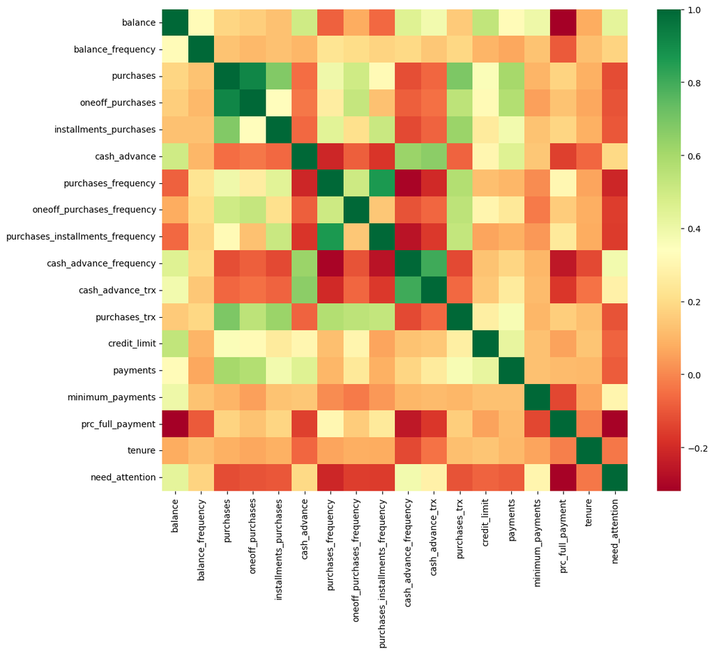

```
High correlation present!
defaultdict(<class 'list'>, {'purchases': ['oneoff_purchases'], 'oneoff_purchases': ['purchases'], 'purchases_frequency': ['purchases_installments_frequency'], 'purchases_installments_frequency': ['purchases_frequency']})
```

The team performed a correlation analysis to identify highly correlated features. Redundant features were removed to prevent multicollinearity and ensure model stability.

```
1. balance: 4.11
2. balance_frequency: 18.11
3. purchases: 58773.75
4. oneoff_purchases: 32776.83
5. installments_purchases: 10399.63
6. cash_advance: 3.46
7. purchases_frequency: 26.45
8. oneoff_purchases_frequency: 5.71
9. purchases_installments_frequency: 17.33
10. cash_advance_frequency: 4.91
11. cash_advance_trx: 3.88
12. purchases_trx: 4.25
13. credit_limit: 4.63
14. payments: 3.6
15. minimum_payments: 1.41
16. prc_full_payment: 1.69
17. tenure: 16.39
```

```
purchases
purchases_frequency
balance_frequency
---
Columns to be dropped:
['purchases', 'purchases_frequency', 'balance_frequency']
```

To further address multicollinearity, we calculated the **Variable Inflation Factor (VIF)** for each numerical feature. Features with high VIF values were considered redundant and excluded from the predictive model.

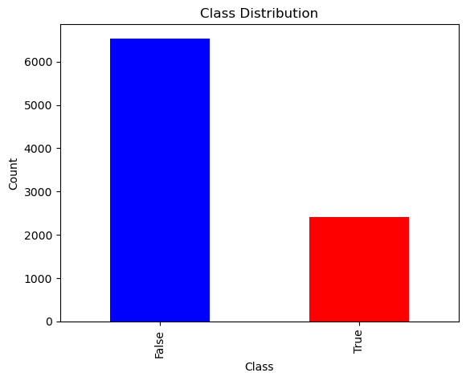

```
Imbalance Ratio: 2.71
```

The dataset exhibits an imbalance ratio of approximately 2.7:1 between negative and positive cases. This could challenge the model’s ability to capture patterns in the minority class. As a mitigation strategy, the team considered resampling techniques (oversampling/undersampling) if predictive performance on unseen data proves inadequate.

```
Train dataset: (7160, 14)(7160,)
Test dataset: (1790, 14)(1790,)
```

Following feature reduction, the dataset was split into **80% training** and **20% testing** sets to facilitate model training and unbiased evaluation.

The team applied feature scaling to the training data to reduce the impact of outliers and noise, ensuring consistent input ranges for the predictive model.

```
LogisticRegression()
```

Logistic regression was selected as the baseline model. If its performance had proven inadequate, alternative models such as **MLP**, **Random Forest**, or **XGBoost** would have been evaluated for re-training and testing.

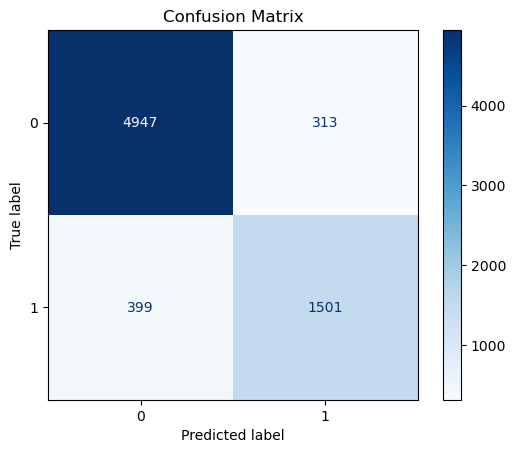

```
Classification Report

              precision    recall  f1-score   support

       False       0.93      0.94      0.93      5260
        True       0.83      0.79      0.81      1900

    accuracy                           0.90      7160
   macro avg       0.88      0.87      0.87      7160
weighted avg       0.90      0.90      0.90      7160
```

Training accuracy was monitored to assess potential overfitting or underfitting, guiding the team in balancing predictive power and generalizability.

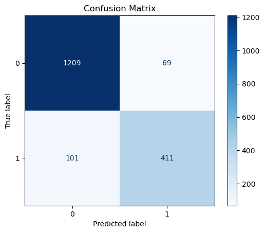

```
Classification Report

              precision    recall  f1-score   support

       False       0.92      0.95      0.93      1278
        True       0.86      0.80      0.83       512

    accuracy                           0.91      1790
   macro avg       0.89      0.87      0.88      1790
weighted avg       0.90      0.91      0.90      1790
```

The logistic regression model demonstrated strong performance, achieving an **F1 score of 83%** and an **overall accuracy of 91%** when predicting the risk flag.

```
array([0.79112272, 0.79224377, 0.81553398, 0.81794195, 0.82113821])
```

```
np.float64(0.8075961254377907)
```

```
np.float64(0.013118703532509705)
```

```
1.62 %
```

5-fold cross-validation confirmed consistent predictive performance, with an average **F1 score of ~81%** and low deviation (~1.3%). Based on these results, the team concludes that logistic regression is sufficient for forecasting the customer risk flag.